# Marking students’ reports

Analysing Data

Milan Valášek

This document gives a short guide on marking students’ submissions. Please make sure you set things up correctly to make this as smooth an experience as it can be for all of us.

## Setting up Canvas API access

As you know, students are supposed to upload R Markdown files for this assignment, which means that we won’t be able to use Canvas/Turnitin for marking. While some – like me might call this a blessing – this does mean that we need a smart way of downloading, marking, and uploading hundreds of documents.

Enter API, or Application Programming Interface. Simply put, an API is a way of retreiving information from and sending information to web applications *programmatically* (using code). If a web application provides an API to the average Jacinda, she can basically do anything her level of authorisation allowes her to do using the standard web interface without as much as opening her browser window. No clicking, no browsing through pages, just good old code. APIs are also very useful for web-scraping and analytics of all sorts. And Twitter and Facebook bots… :/

As luck would have it, Canvas provides a fully exposed [RESTful](https://en.wikipedia.org/wiki/Representational_state_transfer) API which means that uploading all the 500+ marked submissions so that they are only visible to their author can be a matter of seconds rather than hours. In order to access the API, we first need to set up a few things.

### Get access token

First of all, you will need a Canvas access token so that you can authenticate your requests. This will allow Canvas to know who is sending the requests and check if you have the privileges to perform the actions you are attempting.

To do this, log into [Canvas](https://canvas.sussex.ac.uk/) and follow these steps:

1. Go to your account
2. Click on Settings
3. Click on “+ New access token”
4. Put something informative in the Purpose field
5. Choose and expiry date or leave blank for a permanent token (recommended)
6. Click on “Generate token”
7. **Copy the token and paste it into a text file BEFORE you close the pop-up window**
8. Save the text file (*e.g.,* canvas_token.txt) somewhere where you’ll be able to find it.

[figure not shown]

## Install required `R` packages

### `rcanvas`

Unless you’re good enough a coder to write your own API code (and I am certainly not), you’ll need to install the `rcanvas` package from GitHub.

```r
# installing from GitHub requires either package remotes or devtools
remotes::install_github("daranzolin/rcanvas")
```

Feel free to peruse the [package documentation](https://github.com/daranzolin/rcanvas) to find out about all the cool stuff you can do with it.

### `teachR`

While `rcanvas` can do some pretty nifty stuff, it isn’t perfectly tailored to our needs. For instance, it doesn’t provide a function to upload assignment feedback which is basically the main thing we’re after. That’s why you will also need the `teachR` package that extends its functionality to what we need. This is also the package we use to create the teaching materials for the module, in case you’re interested in that.

Again, you’ll have to install `teachR` from GitHub:

```r
remotes::install_github("mivalek/teachR")
```

If `R` prompts you about updating packages, it’s best to update all.

#### The`show.me()` function

The `show.me()` function from `teachR` allows for the integration of marking in a single RStudio window. When called using a report id, it opens up the corresponding Rmd file in RStudio’s source editor and displays the corresponding knitted augmented HTML file in the Viewer pane. This saves you having to switch between multiple windows when marking. Obviously, you are not required to use it but if you think this might be useful, you are welcome to.

The best way to use the function involves setting wour working directory (`setwd()`) using the path to the folder where the Rmd files are located on your computer. Then you can just call the function, passing the sutdent id or Rmd file name to the `id=` argument:

```r
setwd("C:/work/OneDrive - University of Sussex/marking/AnD/2019-20/Milan")
show.me(1234)
# alternatively
show.me("1234.Rmd")
```

### `adata`

Finally, even though we will check students’ results automatically, you might want the ability to have a look at their data yourself. For that, you will need the `adata` package, from where? From GitHub.

```r
remotes::install_github("mivalek/adata", ref="dev")

red <- adata::red_data(123456)
green <- adata::green_data(123456)
```

The package only contains two functions `red_data()` and `green_data()`. They both take a candidate number as their first argument and generate a dataset for the given student.

And with that, you’re all set up for the main event.

## Marking protocol

You will have received links to two R scripts (one for knitting marked Rmd files and one for uploading marked HTML files on Canvas), a Quick comment Google spreadsheet, and an email invitation to share the marking OneDrive folder. Please follow the link and sync the folder with your local Uni OneDrive directory. In the folder, you will find the marking spreadsheet, a folder called “knitted” with the pre-processed HTML reports, and a folder with your name containing the submitted .Rmd files checked for word limit.

**You should use the folder with your name to store marked .Rmd files. Do not move them around.**

### Rubric and grade descriptors

Marking is done according to the following rubric criteria:

- **Analysis:** This component reflects the quality of your statistical analysis and your ability to present and interpret data. To score highly in this area, you must write your code and run your analysis thoroughly and correctly, report all the relevant statistics clearly and correctly, visualise your data appropriately, and demonstrate how well you understand what the results mean.
- **Critical Thinking:** This component captures your ability to evaluate your own and other studies’ findings with a critical eye. To score highly in this area, you must discuss evidence-based criticisms of your own and other studies (not just speculations about what might have gone wrong!); and make insightful, novel, or theoretically interesting suggestions for how to continue this research in the future.
- **Theoretical Understanding:** This component looks at your knowledge and understanding of both the research question and the analysis you have done to answer it. To score highly in this area, you must demonstrate that you understand what your analysis tells you, and discuss how your analysis results do, and do not, inform the overall research question.
- **Organisation:** This component captures your writing, both of text and of R script, and your ability to communicate clearly and scientifically. To score highly in this area, you must write clear, error-free, efficient R code; submit an RMarkdown file that knits correctly and produces a consistently and correctly formatted document; organise your report into sections, each of which summarises the relevant information accurately and succinctly; and communicate your ideas, findings, and evidence in a logical, scientific, and understandable way.
- **Research:** This component reflects the design and grounding of the study you are presenting. To score highly in this area, you must read and reference a variety of academic sources, beyond those given as suggested readings or on the reading list; draw on these wider readings to inform your ideas and understanding of the study; and implement a research design that is appropriate to answer the research question.

You should also have a look at [grade descriptors for each criterion](https://sussex.app.box.com/s/o5nalmzuj6u26w6hh12dq2ni4bks1a37). For further details on marking rubric and criteria, see the accompanying Analysing Data Report Calibration document.

### Marking spreadsheet

Here is where we store the information about students reports, such as file names, candidate numbers, code/knit checks and so on. It is also where you will enter the marks and final grades you are awarding the individual submissions.

**Please do not delete or hide any rows or columns of this spreadsheet as doing so might break the whole thing!**

The spreadsheet contains a “results_ok” column that stores the output of the results-checking function that is run on the reports in pre-processing, before the Rmd files get to you. Because there may be multiple valid ways of analysing the data as well as because of the non-trivial difficulties associated with checking another person’s code, the test is **rather conservative**. That means that if the column does not say `FALSE` you can be pretty sure the results are correct. However, the converse is not necessarily true. Therefore **it is important to consider the reports that have `FALSE` in the corresponding cell of the “results_ok” column on a case-by-case basis**.

### Pre-knitted HTML documents

Before the files get to you, they will be checked for word count and results. The HTML files are stored in the “knitted” folder in the shared OneDrive folder. They will include the correct results and, if the report exceeds the word limit, a note saying so inserted in the appropriate place in the report. In case of a student having reported specific learning difficulties, their report will include a note of this with a link to marking guidelines for SLD.

To aid you in marking, the knitted HTML files also include three buttons at the top of the screen with rubric/grading details, report flowchart previously given to students for guidance, and the Quick comments Google spreadsheet. The latter might need reloading every now and then.

An example of such a file is below (you can see the full-size document with a wider layout [here](https://mivalek.github.io/adata/marking/marking_example.html)).

[interactive chart not shown]

### .Rmd files to mark

The R Markdown files in your subfolder of the shared OneDrive folder are slightly edited versions of the original students’ submissions. The edits are as follows:

- Comments in code are removed
- All `install.packages()` commands are removed
- If word limit is exceeded a line of HTML code is inserted
- A block of feedback HTML and Markdown is appended to the end of the file

The latter looks like this:

```
</div>

\

<a name="feedback"></a>
<div class="feedback">
<!-- THE GOOD -->



<!-- THE BAD -->



<!-- RECOMMENDATIONS -->
```

This is where you enter your general feedback on students’ work.

**Please do not delete any part of this code!**

An example Rmd file corresponding to the HTML document above can be found [here](https://mivalek.github.io/adata/marking/marking_example.Rmd) (link will download the file).

## Commenting on .Rmd files

### In-line comments

The marked .Rmd files are knitted using the `teachR::mark()` function that allows additional markdown for comments in body text. These comments are fenced off with `<–tag [your comment]–>`. There are 6 recognised tags: `warn` for general comments/warnings and `c1` to `c5` for comments on each of the marking rubric criteria.

To illustrate, the following comments:

[output not shown]

…will render like this:

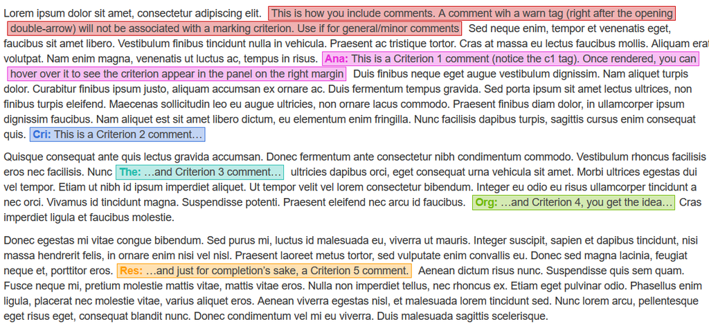

#### Quick comments

Apart from the main marking sheet, the Google spreadsheet contains a “Quick_comment” sheet where you can find some redy-in-the-oven comments on issues we expect to reoccur. They comments are organised by marking criterion. You can skim the first column of the sheet for a quick lookup of the issue. When you find a comment you’d like to use, all you need to do is copy the content of the cell in the “markdown” column and paste it directly in the Rmd file you are marking.

If you find yourself reusing a comment that is not in the sheet, please feel free to add it. Insert a new line under the appropriate heading, copy and paste the existing quick comment above, and edit it. The “markdown” column should get populated automatically. Contributing your frequent comments will make marking easier for everyone.

### Code chunk comment

The reason why all code comments get stripped in pre-processing is so that you can use them to comment on students’ code. Use them the same way you would use ordinary `#comments`. Once knitted, the leading hash will get removed and the comments will be formatted similarly to the in-text comments.

For instance, the following code chunk:

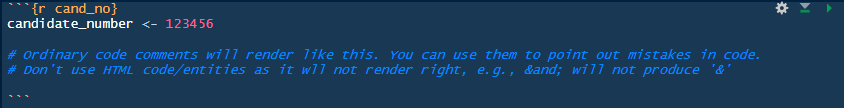

…will render like this:

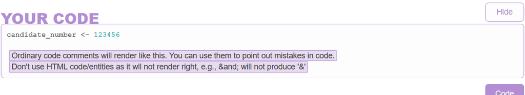

### Feedack

As mentioned above, there’s some extra HTML/Markdown appended to the end of the students’ .Rmd files. This is where you give general summary feedback on their performance. Any R Markdown will work normally. In post-processing, the three placeholders (`<!–- THE GOOD -–>`, `<!–- THE BAD –->`, and `<!–- RECOMMENDATIONS –->`) will get replaced by boilerplate text (see bottom of the example document below). That means that it’s enough for you just to include a few bulletpoints highlighting the report’s strengths, weaknesses, and giving some general recommendations for improvement.

Once a marked and commented .Rmd file has been knitted, it will look like the example below (you can see the full-size document with a wider layout [here](https://mivalek.github.io/adata/marking/marked_example_marked.html)). As mentioned, the in-line comments are interactive and reveal the matching rubric criterion description on hover. The boxes with partial grades per criterion are also interactive and when clicked, reveal the grade descriptor.

[interactive chart not shown]

## Awarding marks

Even though the mark scale spans the [0, 100] interval, the university marking policy doesn’t allow all the values within this range. Please only award marks listed in [the grade descriptor document](https://sussex.app.box.com/s/o5nalmzuj6u26w6hh12dq2ni4bks1a37), namely:

- 0, 10, 20, 30
- 35, 38
- 42, 45, 48,
- 52, 55, 58,
- 62, 65, 68
- 72, 75, 78,
- 82, 88,
- 95

Mark the reports on each of the rubric criteria and award a numeric mark, entering it in the Google sheet. The spreadsheet then calculates the average of the five marks and shows it in the “suggested_grade” column. This mark is not binding for you as the marker but you should have a good reason for big departures from it in the total grade you enter in the “grade” column. Please bear in mind that the total grade should also follow the marking policy and its numeric value should only be one of the allowed ones. For example, you can use the suggest grade to help you decide whether to mark up or down on a grade boundary (e.g. either a 62 or a 58, since you cannot give a 60).

## Knitting marked .Rmd files

Once you have commented **all .Rmd files and entered all the partial and total grades** in the marking spreadsheet, the module convenor will arrange moderation. Once the marks have been moderated and any necessary changes to marks have been made, you will need to knit the files to produce the augmented HTML documents. The code for this will have been shared with you (marking_script.R).

The only thing you need to edit in the script before your run it is the bit towards the beginning (but see below for edits for calibration marking):

```r
######################## EDIT AS APPROPRIATE ################################
# EDIT PATH to the OneDrive folder we shared with you
marking_path <- "C:/work/OneDrive - University of Sussex/marking/AnD/2019-20/Milan"
```

The marking_spreadsheet.xlsx **must not be open** when you are running the code, otherwise `R` won’t be able to read it in.

The path should point to the synced OneDrive folder containing the commented .Rmd files. The files should not be in separate subfolders.

Before actual marking starts, you will receive a small number of selected reports to mark for the purpose of calibration. All markers receive the same reports and mark them independently form one another. Because of this, the .Rmd files are not shared via OneDrive and there is no master marking spreadsheet. Instead, you will be emailed the calibration sample and a link to a Google sheet **you need to download as a CSV file**. You will use this local copy to enter the marks. Please save all files into a single folder on your computer. When you have finished marking the claibration sample, you can use the same marking_script.R file to knit the reports to HTML.

However, because of these differences, you need to slightly change the way you edit the file in two ways:

```r
######################## EDIT AS APPROPRIATE ################################
# EDIT PATH to the OneDrive folder we shared with you
marking_path <- "path/to/where/you/saved/the/calibration/files"

marks <- readxl::read_xlsx(file.path(marking_path, "../marking_spreadsheet.xlsx"))
# marks <- read.csv("path/to/csv/file.csv", stringsAsFactors = F)
#############################################################################
```

After that, you can simply run the script and, once knitted, save the HTML files into the shared Calibration folder on OneDrive.

## Uploading marked HTML files

The module covenor will let you know once it is time to upload the HTML files back onto Canvas.

To do that, you should run the code in the canvas_upload.R script that will have been shared with you. Once, again, there are two things you need to edit before you can run the code:

1. Change the path to point it to the folder with the knitted HTML files.
2. Insert your Canvas access token inside the "s.

```r
######################## EDIT AS APPROPRIATE ################################
# EDIT PATH to the OneDrive folder we shared with you
fpath <- "marking/AnD/2019-20"
# insert your Canvas token
canvas_token <- ""
#############################################################################
```

The code will then upload the HTML documents as feedback attachments to each individual student submission. Again, this may take a minute.

## Procedure overview

Now that you are familiar with the individual components of the marking protocol, all you need to do is follow these few steps.

1. Complete the setup detailed above.
   - Get and save a Canvas access token
   - Install the `rcanvas`, `teachR`, and `adata` packages.
2. Sync the shared OneDrive with your local OneDrive directory. There you will find your allocated .Rmd files (stored in a folder with your name).
3. Download the marking_script.R and canvas_upload.R files you’ve been linked to.
4. Open the marking_spreadsheet.xlsx in the shared OneDrive folder.
5. Read the HTML file while commenting on the report inside the .Rmd file as detailed above.
   - **Do not change the file names!**
   - The `show.me()` function from `teachR` comes in handy here as it allows you to have everything open in a single RStudio window.
6. Enter marks per each rubric criterion and a total grade into the master marking spreadsheet.
7. Once the module convenor has notified you that moderation has been completed, run the code inside marking_script.R, editing as appropriate.
   - Make sure you close the marking_spreadsheet.xlsx file before you run the script!
8. Make sure all your marked .Rmd and knitted HTML files are in your subfolder of the OneDrive folder.
9. Once you get the thumbs up from the module convenor, run the code inside canvas_upload.R to upload the files back onto Canvas.
10. Check a few submissions on Canvas to see if the upload went through and that matching files were attached to students’ submissions.
11. Email the module convenor, cc’ing the lecturers, letting them know that you have finished the upload.
12. If you have any issues, please let us know as soon as possible.

That is all you need to know to get going on the marking. Thank you so much for all your hard work!